# Utilize your Tools - Tutorials (1/2)

https://github.com/kekistermann/Exploring-the-PsychometricToolbox

# Import the dataset

Data is available here: https://osf.io/jmz2n/overview (contains “data_affect.csv”)

```r
library(tidyverse)
```

```r
# define variable names
# c("happy", "excited", "relaxed", "satisfied", "angry","anxious", "depressed", "sad")
variables <- c("hap", "exc", "rel", "sat", "ang","anx", "dep", "sad") #shorter names for better Figures later

# Read in the CSV file, arrange the data & rename the 6 emotion variables
data <- read_csv("data_affect.csv", na = "") %>%
  arrange(subjno, group, dayno, beep) %>%
  rename_with(~ variables, .cols = c("emo1_m", "emo2_m", "emo3_m", "emo4_m", "emo5_m", "emo6_m", "emo7_m", "emo8_m"))
# create a subset with only group 1 (control)
data_group1 <- data %>%
  filter(group == 1)

# create a subset with only group 2 (mindfulness training)
data_group2 <- data %>%
  filter(group == 2)

# count the number of people in each group
data %>%
  distinct(group, subjno) %>%
  count(group)
```

```
## # A tibble: 2 × 2
##   group     n
##   <dbl> <int>
## 1     1    64
## 2     2    61
```

# multilevel VAR (mlVAR)

https://cran.r-project.org/web/packages/mlVAR ## ‘mlvar()’ “The function ‘mlvar()’ computes estimates of the multivariate vector autoregression model. This model returns three stuctures: temporal effects (e.g., lag-1 regression weights), contemporaneous relationships (correlations or partial correlations) and between-subject effects (correlations and partial correlations).” https://cran.r-project.org/web/packages/mlVAR/refman/mlVAR.html#mlVAR

```r
library(mlVAR)

#estimating mlVAR model
mlvar_all <- mlVAR(data,
                     vars = variables,
                     idvar = "subjno",
                     lags = 1,
                     dayvar = "dayno",
                     beepvar = "beep")
```

```
## 'estimator' argument set to 'lmer'
```

```
## 'temporal' argument set to 'orthogonal'
```

```
## 'contemporaneous' argument set to 'orthogonal'
```

```
## Estimating temporal and between-subjects effects
```

[output not shown]

```
## Estimating contemporaneous effects
```

[output not shown]

```
## Computing random effects
```

[output not shown]

```r
mlvar_group1 <- mlVAR(data_group1,
                     vars = variables,
                     idvar = "subjno",
                     lags = 1,
                     dayvar = "dayno",
                     beepvar = "beep")
```

```
## 'estimator' argument set to 'lmer'
```

```
## 'temporal' argument set to 'orthogonal'
```

```
## 'contemporaneous' argument set to 'orthogonal'
```

```
## Estimating temporal and between-subjects effects
```

[output not shown]

```
## Estimating contemporaneous effects
```

[output not shown]

```
## Computing random effects
```

[output not shown]

```r
mlvar_group2 <- mlVAR(data_group2,
                     vars = variables,
                     idvar = "subjno",
                     lags = 1,
                     dayvar = "dayno",
                     beepvar = "beep")
```

```
## 'estimator' argument set to 'lmer'
```

```
## 'temporal' argument set to 'orthogonal'
```

```
## 'contemporaneous' argument set to 'orthogonal'
```

```
## Estimating temporal and between-subjects effects
```

[output not shown]

```
## Estimating contemporaneous effects
```

[output not shown]

```
## Computing random effects
```

[output not shown]

### Summary statistics of ‘mlVAR()’ output with ‘summary()’

“Prints tables with fit indices and parameter estimates.” https://cran.r-project.org/web/packages/mlVAR/refman/mlVAR.html#summary.mlVAR

```r
#summary(mlvar_all)
#summary(mlvar_group1)
#summary(mlvar_group2)
```

### Plotting the output of ‘mlVAR()’ with ‘plot()’

“plots estimated model coefficients as networks using qgraph. These can be three networks: temporal, contemporaneous and between-subjects effects, of which the latter two can be plotted as a correlation or a partial correlation network.” https://cran.r-project.org/web/packages/mlVAR/refman/mlVAR.html#plot.mlVAR

#### generate Figure 9 in Publication

```r
jpeg("figure_mlVAR.jpg", width = 1500, height = 2000, res = 300)
layout(matrix(1:6, nrow = 3, ncol = 2, byrow = TRUE))

plot(mlvar_group1, "temporal", title = "temporal (A)", layout = "circle", nonsig = "hide", theme = "gray", vsize = 13)
plot(mlvar_group2, "temporal", title = "temporal (B)", layout = "circle", nonsig = "hide", theme = "gray", vsize = 13)


plot(mlvar_group1, "contemporaneous", title = "contemporaneous (A)", layout = "circle", nonsig = "hide", theme = "gray", vsize = 13)
plot(mlvar_group2, "contemporaneous", title = "contemporaneous (B)", layout = "circle", nonsig = "hide", theme = "gray", vsize = 13)

# Plot between-persons partial correlations
plot(mlvar_group1, "between", title = "between (A)", layout = "circle", nonsig = "hide", theme = "gray", vsize = 13)
plot(mlvar_group2, "between", title = "between (B)", layout = "circle", nonsig = "hide", theme = "gray", vsize = 13)

dev.off()
```

#### temporal network (lag-1 relations):

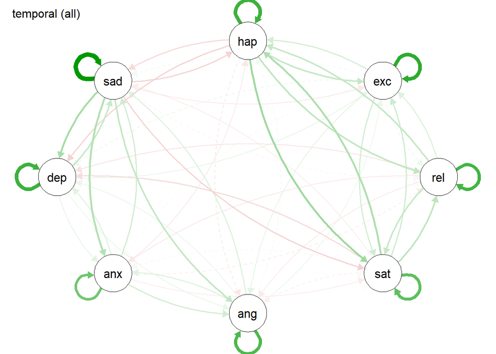

```r
plot(mlvar_all, "temporal", title = "temporal (all)", layout = "circle", nonsig = "dashed")
```

```
## 'nonsig' argument set to: 'show'
## 'nonsig' argument set to: 'show'
```

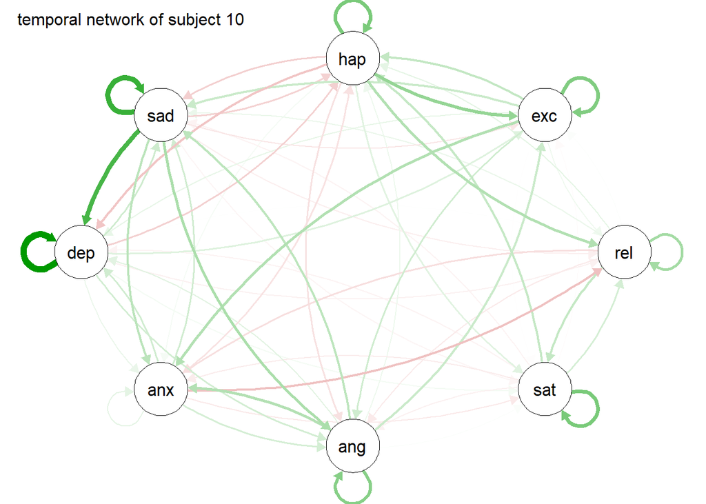

```
## 'nonsig' argument set to: 'show'
## 'nonsig' argument set to: 'show'
```

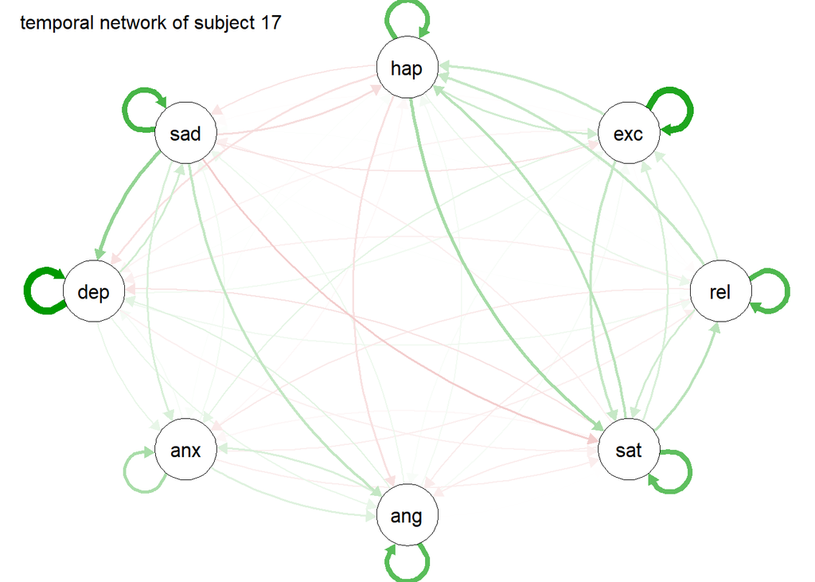

```
## 'nonsig' argument set to: 'show'
## 'nonsig' argument set to: 'show'
```

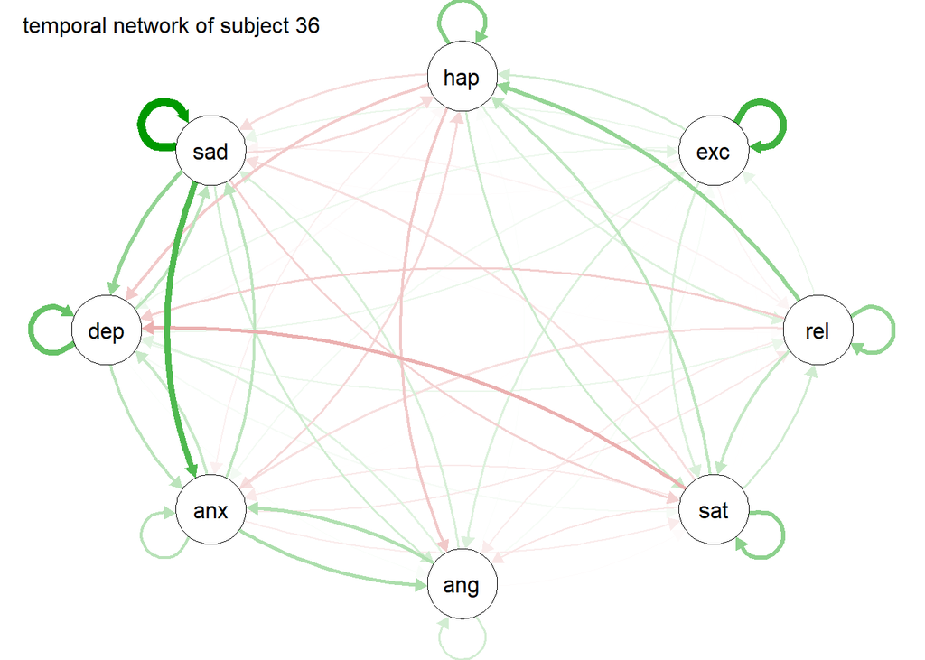

```
## 'nonsig' argument set to: 'show'
## 'nonsig' argument set to: 'show'
```

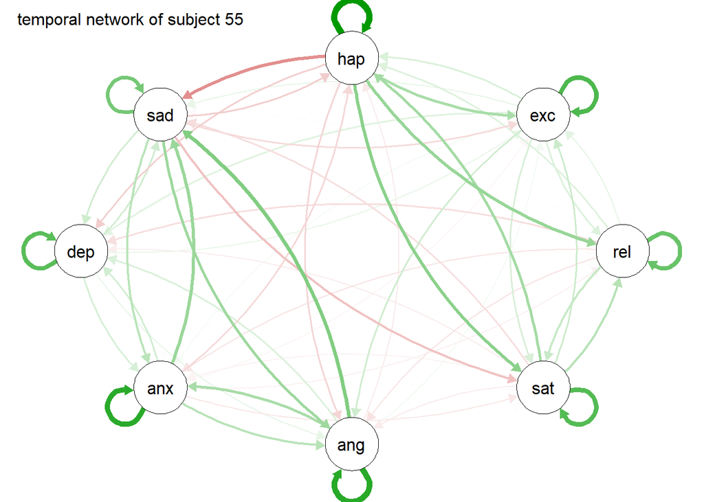

```
## 'nonsig' argument set to: 'show'
## 'nonsig' argument set to: 'show'
```

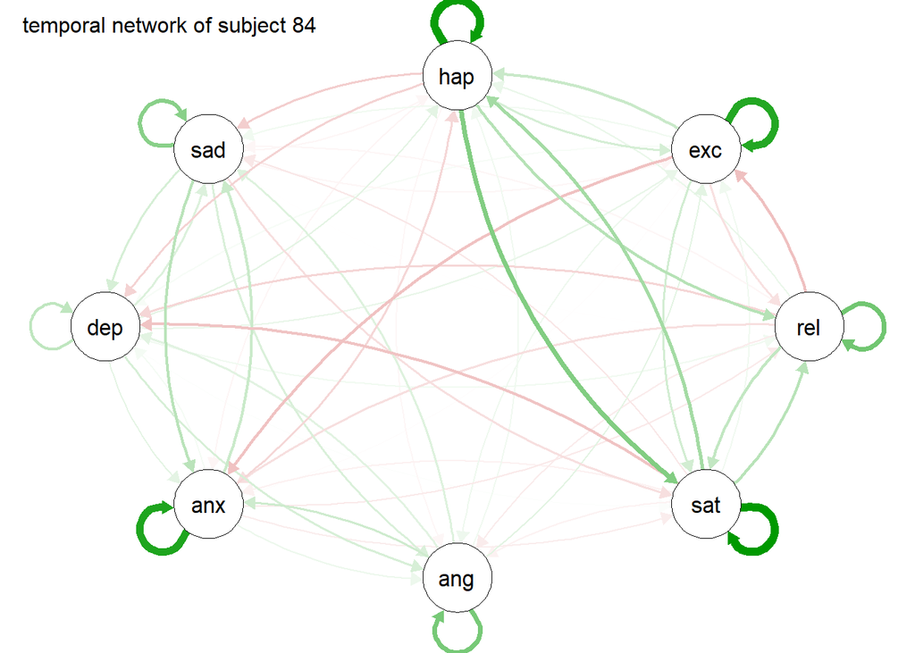

```
## 'nonsig' argument set to: 'show'
## 'nonsig' argument set to: 'show'
```

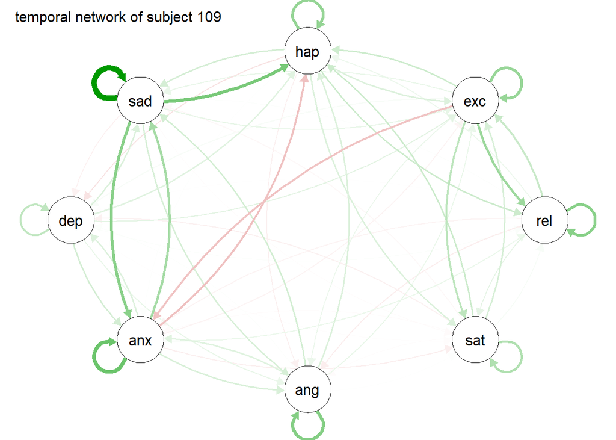

```r
# plot random sample of individual temporal networks
subjects <- c(10, 17, 36, 55, 84, 109)

# plot + save all figures
for (s in subjects) {

  plot(mlvar_all, "temporal",
       title = paste0("temporal network of subject ", s),
       subject = s,
       layout = "circle"
       )

  jpeg(filename = paste0("figure_temporal_network_", s, ".jpg"),
       width = 2000,
       height = 2000,
       res = 300)

  plot(mlvar_all, "temporal",
       title = paste0("temporal network of subject ", s),
       subject = s,
       layout = "circle"
       )

  dev.off()
}
```

#### contemporaneous network:

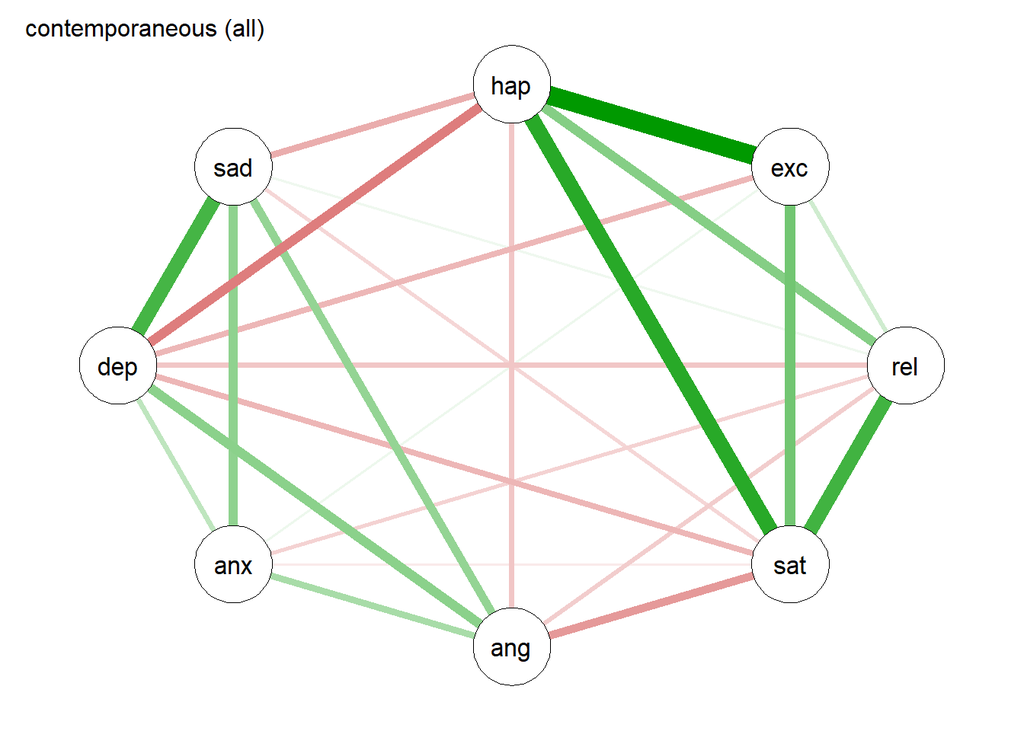

```r
plot(mlvar_all, "contemporaneous", title = "contemporaneous (all)", layout = "circle", nonsig = "hide")
```

```
## 'nonsig' argument set to: 'show'
## 'nonsig' argument set to: 'show'
```

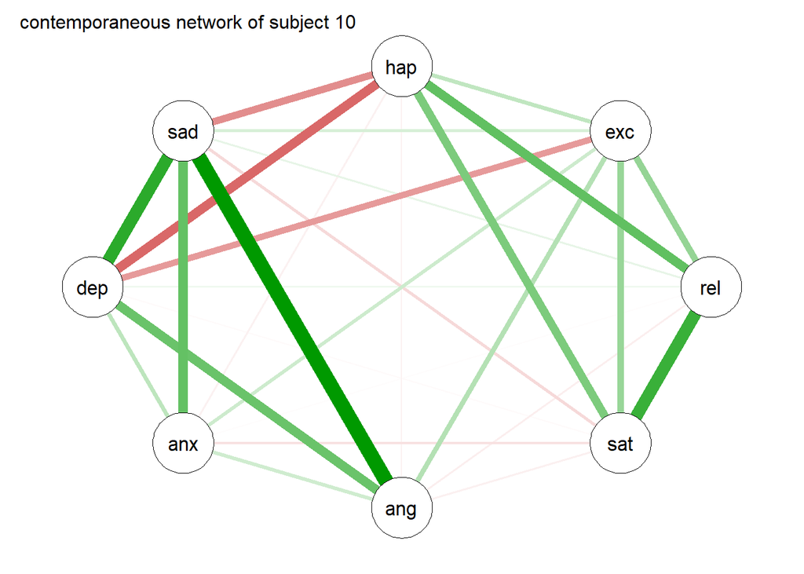

```
## 'nonsig' argument set to: 'show'
## 'nonsig' argument set to: 'show'
```

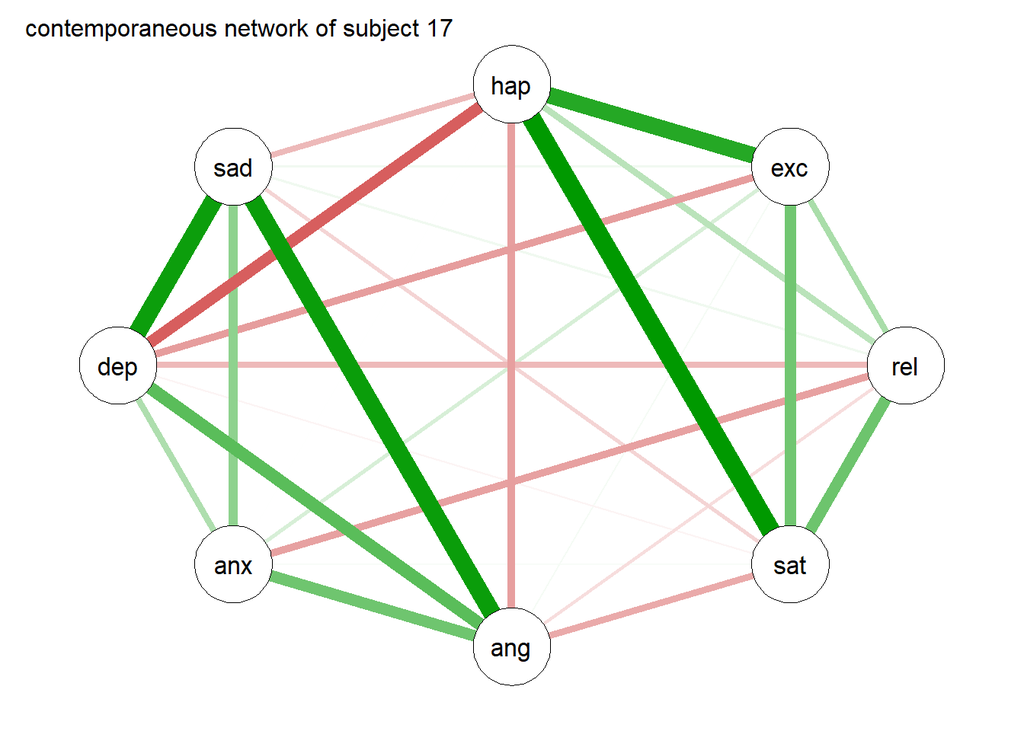

```
## 'nonsig' argument set to: 'show'
## 'nonsig' argument set to: 'show'
```

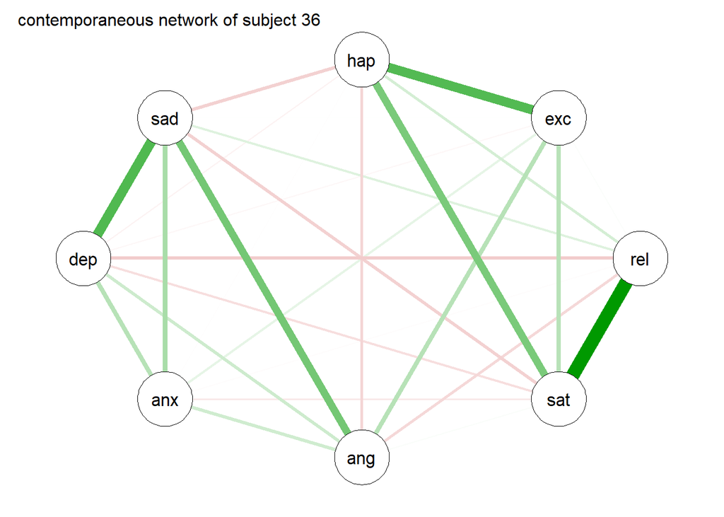

```
## 'nonsig' argument set to: 'show'
## 'nonsig' argument set to: 'show'
```

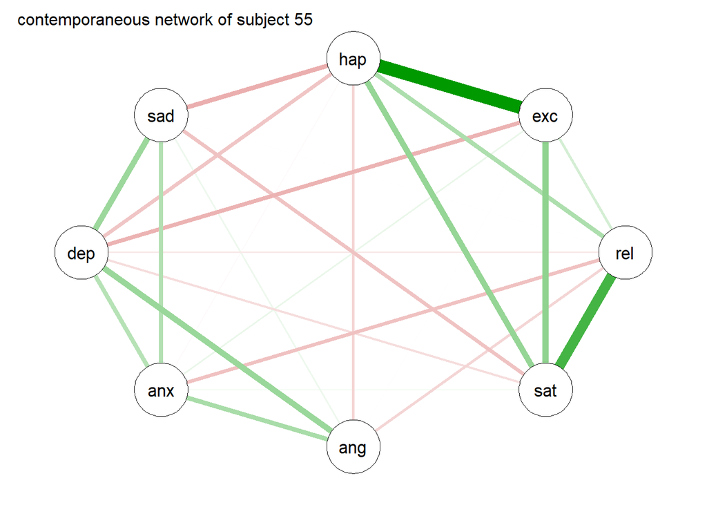

```
## 'nonsig' argument set to: 'show'
## 'nonsig' argument set to: 'show'
```

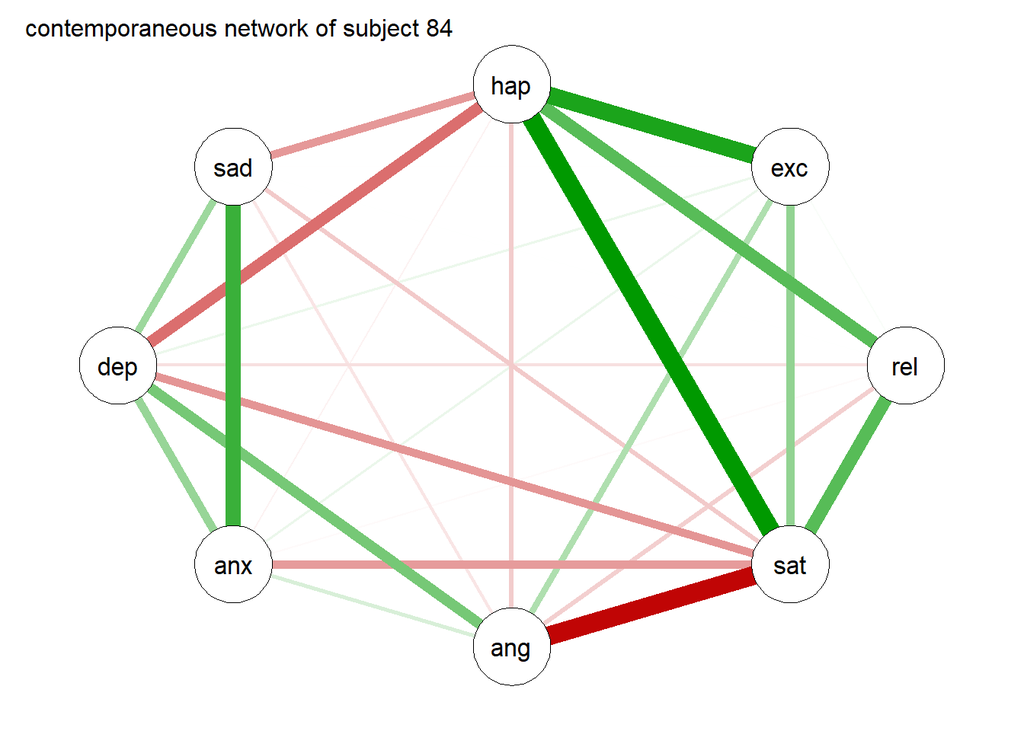

```
## 'nonsig' argument set to: 'show'
## 'nonsig' argument set to: 'show'
```

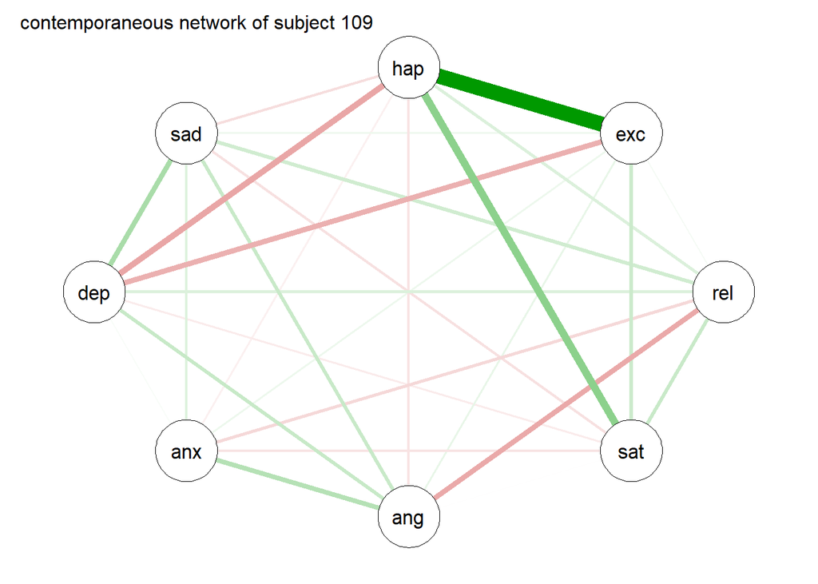

```r
# plot individual contemporaneous networks + save all figures
for (s in subjects) {

  plot(mlvar_all, "contemporaneous",
       title = paste0("contemporaneous network of subject ", s),
       subject = s,
       layout = "circle"
       )

  jpeg(filename = paste0("figure_contemporaneous_network_", s, ".jpg"),
       width = 2000,
       height = 2000,
       res = 300)

  plot(mlvar_all, "contemporaneous",
       title = paste0("contemporaneous network of subject ", s),
       subject = s,
       layout = "circle"
       )

  dev.off()
}
```

# Group Iterative Multiple Model Estimation (GIMME) framework

https://cran.r-project.org/web/packages/gimme/index.html ## Transform data in format required for ‘gimme()’

```r
# transform our tbl_df into the format required for gimme()
data_GIMME <- data %>%
  group_by(subjno) %>%
  group_split() %>%
  lapply(function(df)
    {df %>%
      select(-subjno, -dayno, -beep, -group) %>% # remove all columns that are not variables
      as.data.frame() # gimme prefers base data.frames
      })

data_GIMME_1 <- data_group1 %>%
  group_by(subjno) %>%
  group_split() %>%
  lapply(function(df)
    {df %>%
      select(-subjno, -dayno, -beep, -group) %>% # remove all columns that are not variables
      as.data.frame() # gimme prefers base data.frames
      })

data_GIMME_2 <- data_group2 %>%
  group_by(subjno) %>%
  group_split() %>%
  lapply(function(df)
    {df %>%
      select(-subjno, -dayno, -beep, -group) %>% # remove all columns that are not variables
      as.data.frame() # gimme prefers base data.frames
      })
```

## GIMME: for each group (control and mindfulness intervention) separately

### Estimate a GIMME for Group 1 (control)

**Here again, differences in individual network topology are apparent.**

```r
library(gimme)
GIMME <- gimme(data = data_GIMME_1)
```

[output not shown]

[output cut: 79 more lines]

[output not shown]

[output not shown]

[output not shown]

[output not shown]

[output not shown]

```
## Please specify a file id for individual plots. Otherwise, summary plot is presented.
```

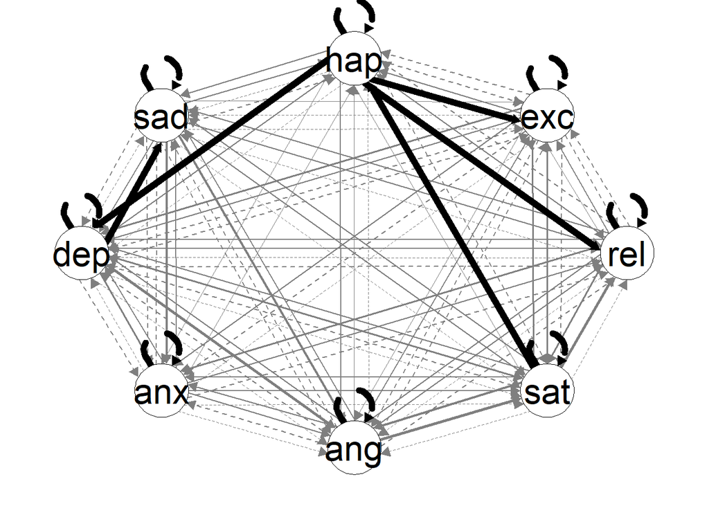

```r
plot(GIMME)
```

```r
# generate figure
jpeg("figure_GIMME_control.jpg", width = 1000, height = 1000, res = 300)
plot(GIMME)
```

```
## Please specify a file id for individual plots. Otherwise, summary plot is presented.
```

```r
dev.off()
```

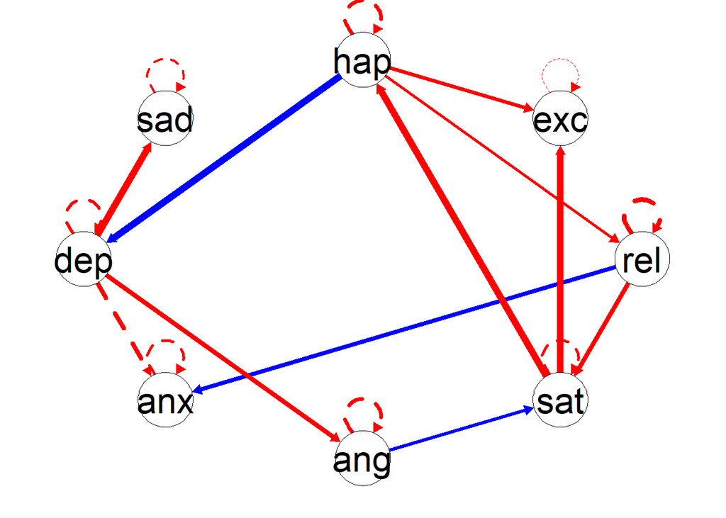

```r
# plot random sample of individual networks
plot(GIMME$plots$subj4)
```

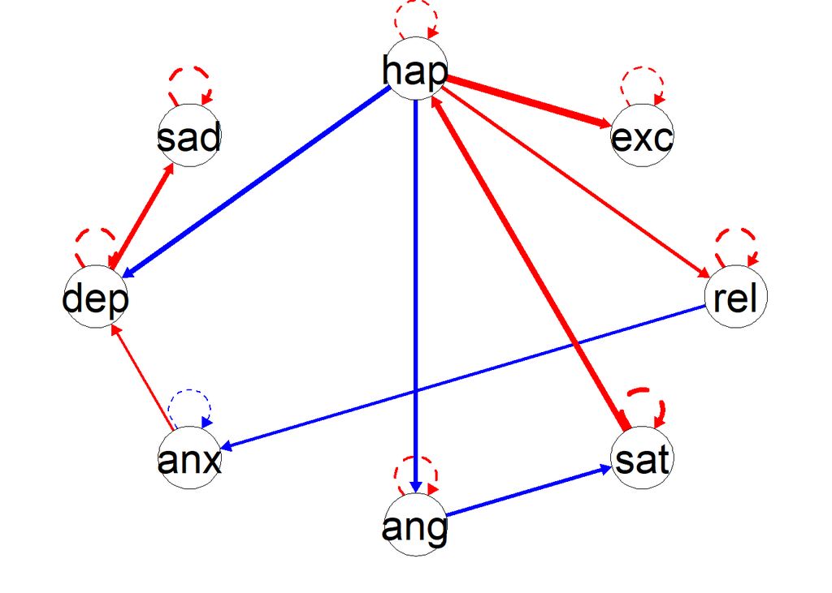

```r
plot(GIMME$plots$subj17)
```

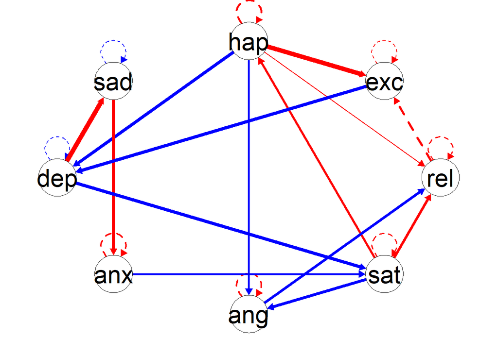

```r
plot(GIMME$plots$subj52)
```

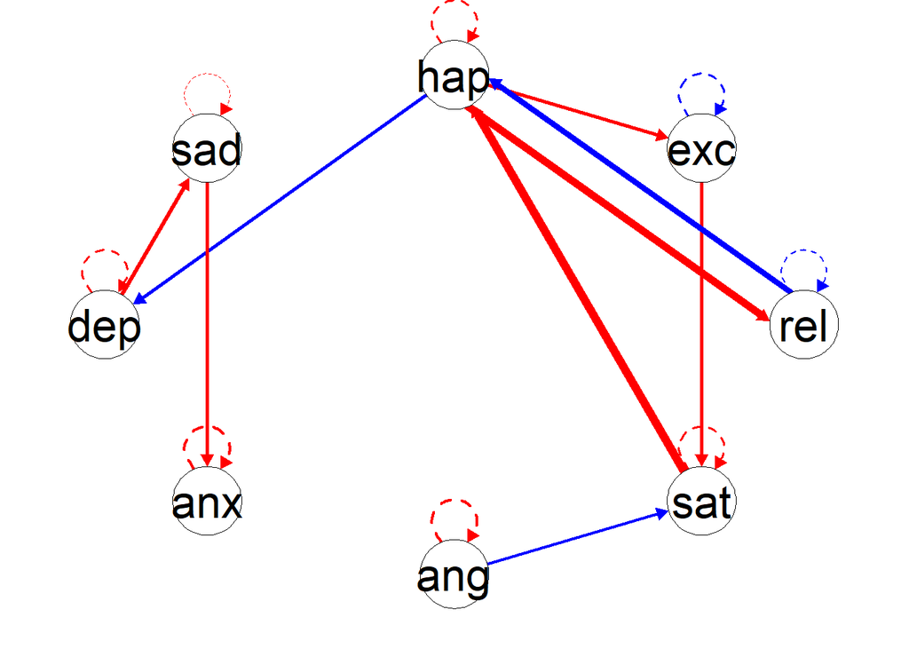

```r
plot(GIMME$plots$subj62)
```

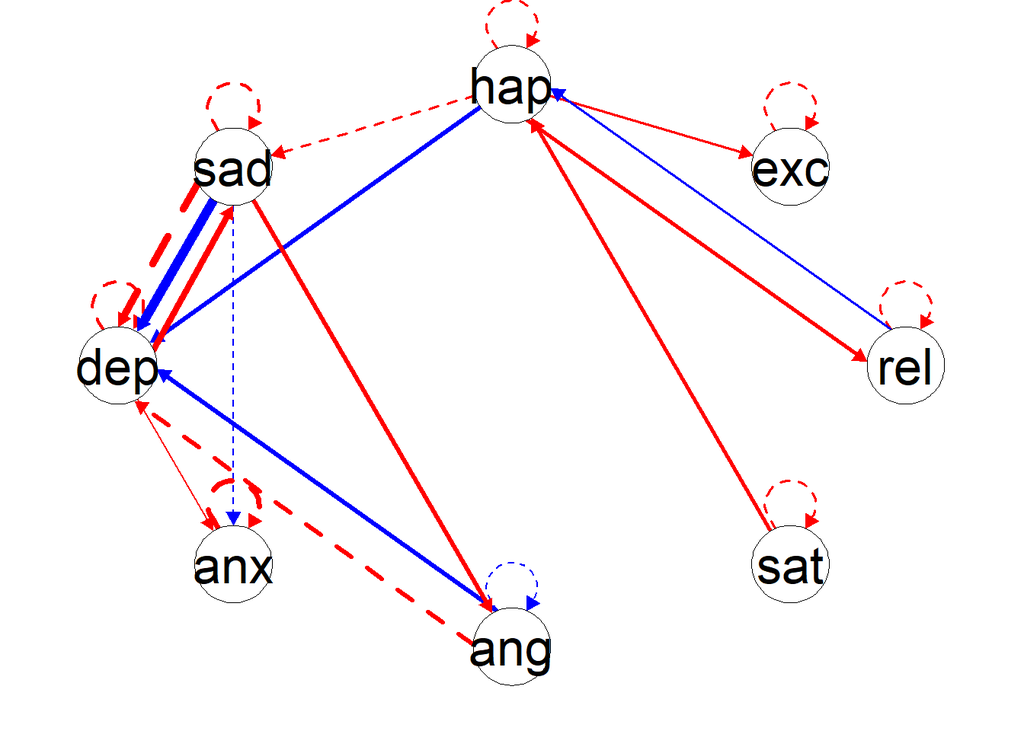

```r
plot(GIMME$plots$subj36)
```

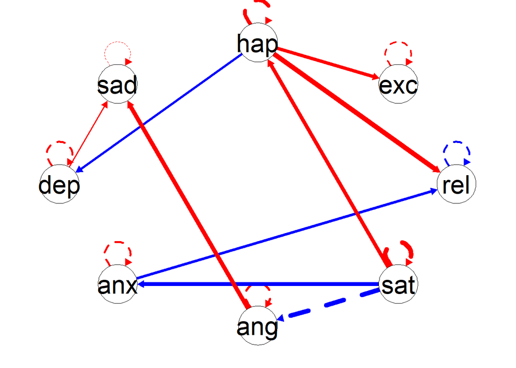

```r
plot(GIMME$plots$subj53)
```

```r
# generate Figure
jpeg("figure_GIMME_control_individuals.jpg", width = 1500, height = 1500, res = 300)
layout(matrix(1:6, nrow = 3, ncol = 2, byrow = TRUE))
plot(GIMME$plots$subj4)
plot(GIMME$plots$subj17)
plot(GIMME$plots$subj52)
plot(GIMME$plots$subj62)
plot(GIMME$plots$subj36)
plot(GIMME$plots$subj53)
dev.off()
```

### Estimate a GIMME for Group 2 (intervention)

**Here too, but how to compare them?**

```r
GIMME_2 <- gimme(data = data_GIMME_2)
```

[output not shown]

[output cut: 80 more lines]

[output not shown]

```
## Please specify a file id for individual plots. Otherwise, summary plot is presented.
```

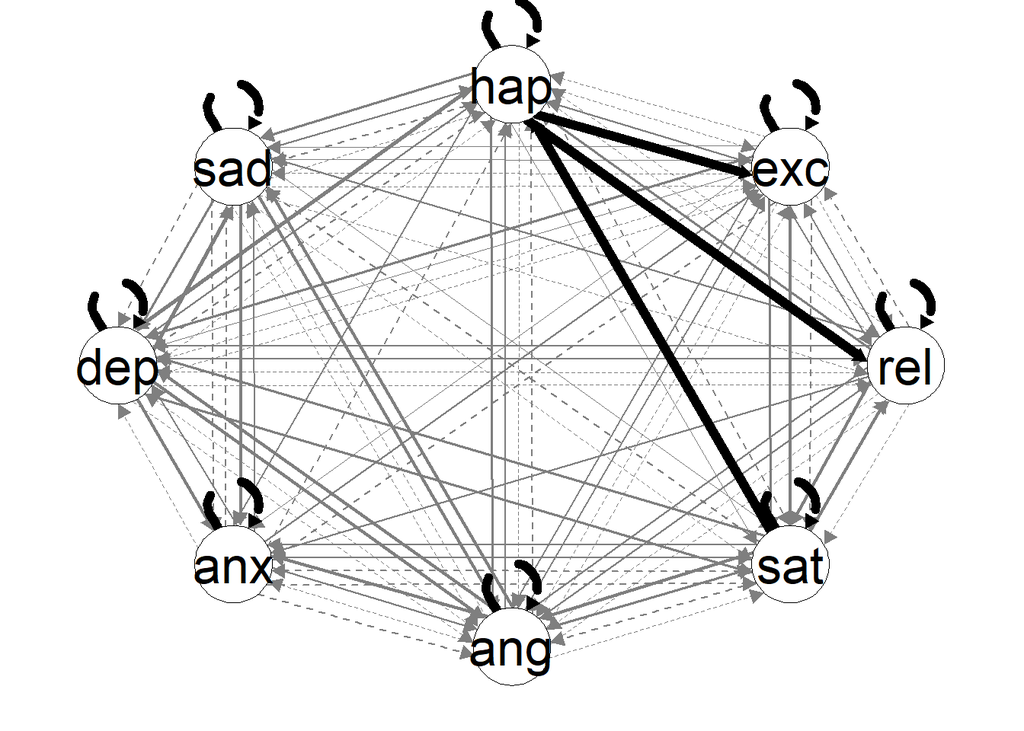

```r
plot(GIMME_2)
```

```r
# generate figure
jpeg("figure_GIMME_intervention.jpg", width = 1000, height = 1000, res = 300)
plot(GIMME_2)
```

```
## Please specify a file id for individual plots. Otherwise, summary plot is presented.
```

```r
dev.off()
```

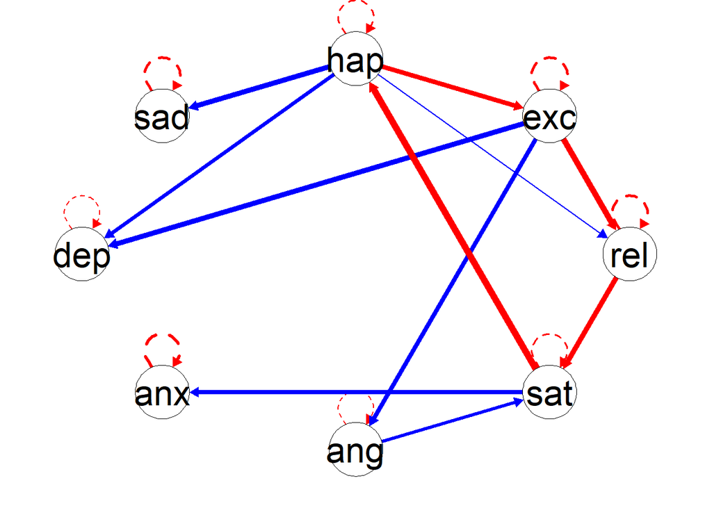

```r
# plot random sample of individual networks
plot(GIMME_2$plots$subj1)
```

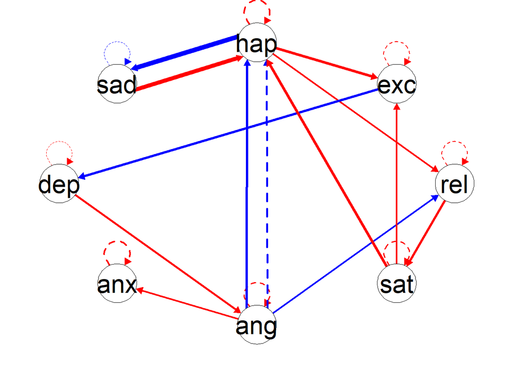

```r
plot(GIMME_2$plots$subj31)
```

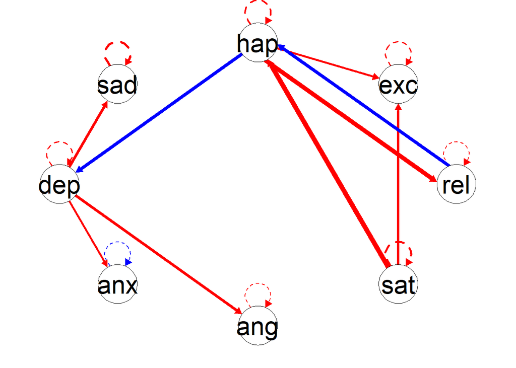

```r
plot(GIMME_2$plots$subj51)
```

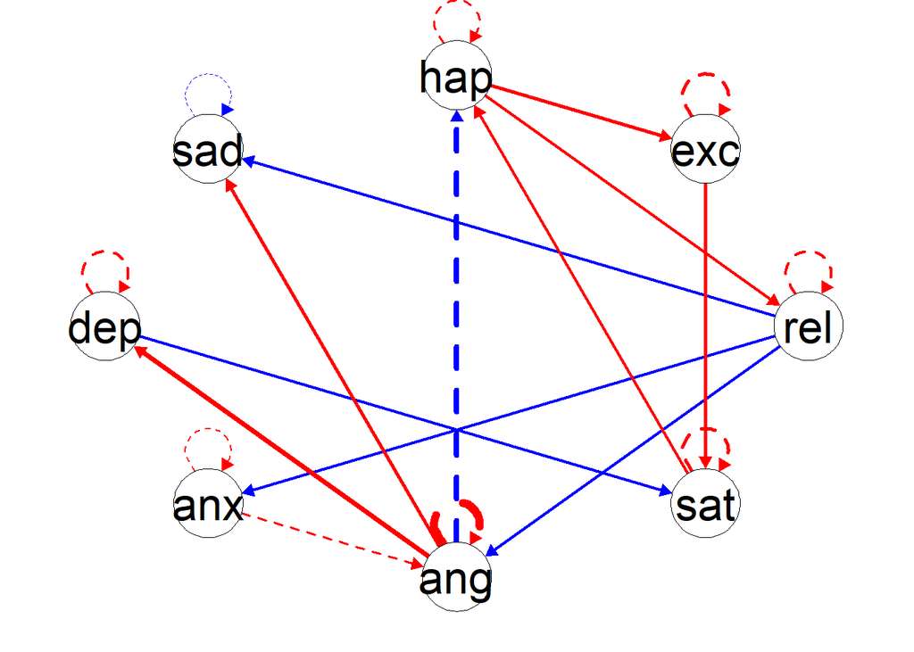

```r
plot(GIMME_2$plots$subj57)
```

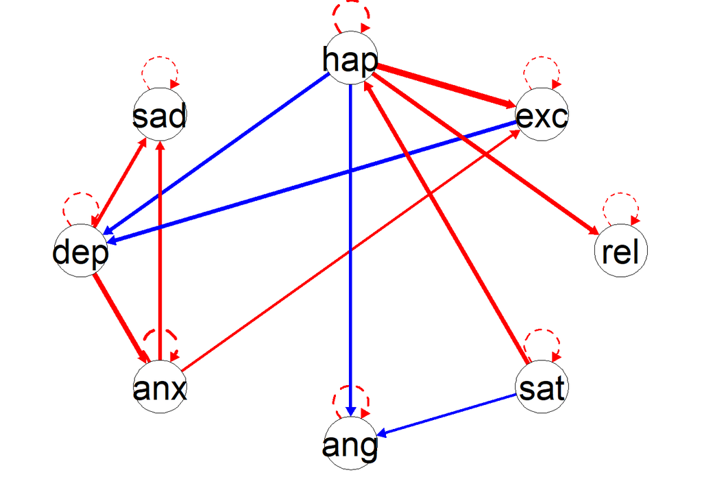

```r
plot(GIMME_2$plots$subj16)
```

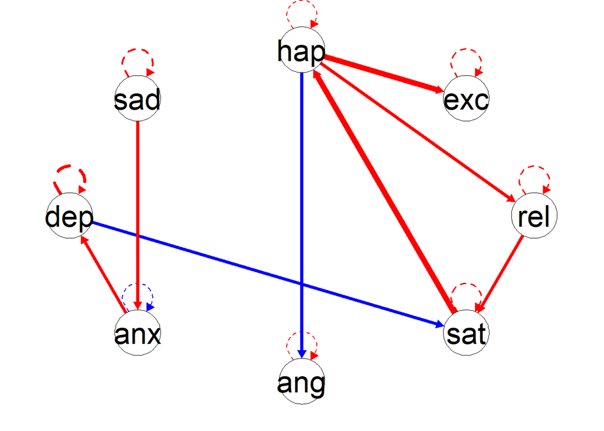

```r
plot(GIMME_2$plots$subj27)
```

```r
# generate Figure
jpeg("figure_GIMME_intervention_individuals.jpg", width = 1500, height = 1500, res = 300)
layout(matrix(1:6, nrow = 3, ncol = 2, byrow = TRUE))
plot(GIMME_2$plots$subj1)
plot(GIMME_2$plots$subj31)
plot(GIMME_2$plots$subj51)
plot(GIMME_2$plots$subj57)
plot(GIMME_2$plots$subj16)
plot(GIMME_2$plots$subj27)
dev.off()
```

## S-GIMME

“conducts the community-detection algorithm Walktrap (Pons & Latapy, 2006) on temporal features available during GIMME model building. After arriving at the group-level effects, S-GIMME identifies effects that may be specific to each subgroup. Finally, as with the original GIMME algorithm, S-GIMME conducts individual-level searches. All weights are estimated at the individual level-even for those dynamic relations found to exist at the group or subgroup levels. Importantly, the researcher does not need to decide the number of subgroups - the algorithm finds the number. The final models contain reliable group-, subgroup-, and individual-level patterns that enable generalizable inferences, subgroups of individuals with shared model features, and individual-level patterns and estimates.”

```r
library(gimme)

S_GIMME <- gimme(data        = data_GIMME,
                 subgroup    = TRUE,
                 sub_feature = "lag & contemp",
                 sub_method  = "Walktrap",
                 groupcutoff = .75,
                 subcutoff   = .75)
```

[output not shown]

[output cut: 282 more lines]

[output not shown]

[output not shown]

[output cut: 17 more lines]

[output not shown]

[output not shown]

[output not shown]

```
## individual-level search, subject 121 (subj121)
## individual-level search, subject 122 (subj122)
## individual-level search, subject 123 (subj123)
## individual-level search, subject 124 (subj124)
## individual-level search, subject 125 (subj125)
```

```
## gimme finished running normally
## Number of subgroups = 2
## Modularity = 0.03239
```

```
## Please specify a file id for individual plots. Otherwise, summary plot is presented.
```

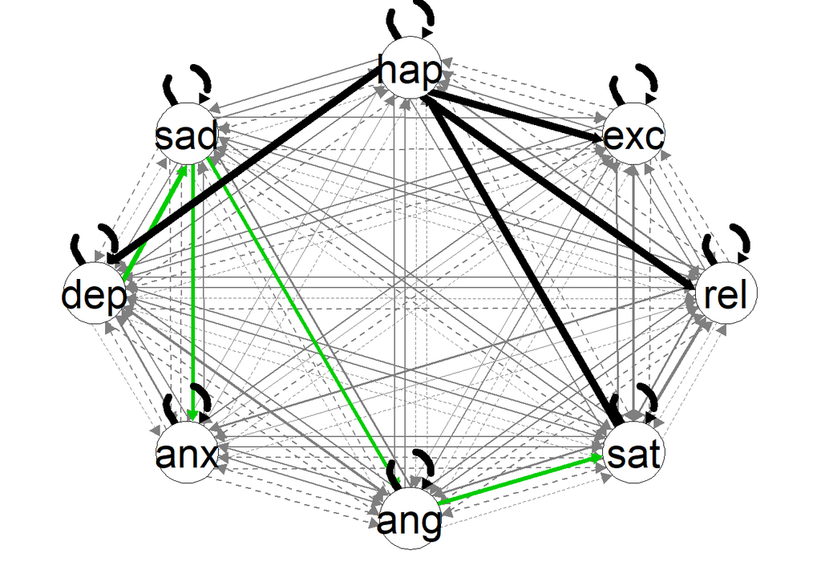

```r
plot(S_GIMME)
```

```r
# generate figure
jpeg("figure_S-GIMME.jpg", width = 1000, height = 1000, res = 300)
plot(S_GIMME)
```

```
## Please specify a file id for individual plots. Otherwise, summary plot is presented.
```

```r
dev.off()
```

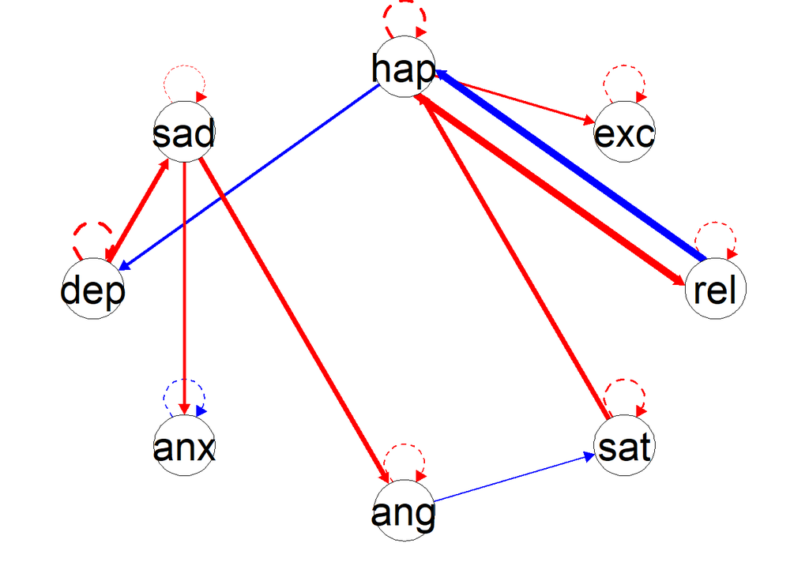

```r
# Plot random sample of individual networks
plot(S_GIMME$plots$subj10)
```

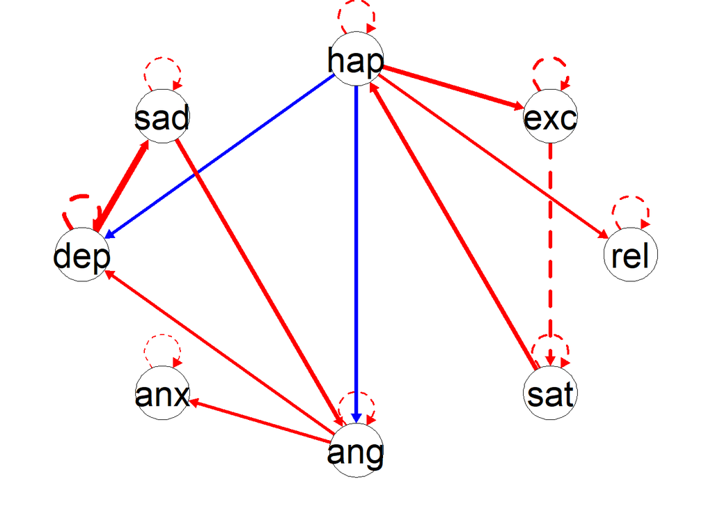

```r
plot(S_GIMME$plots$subj17)
```

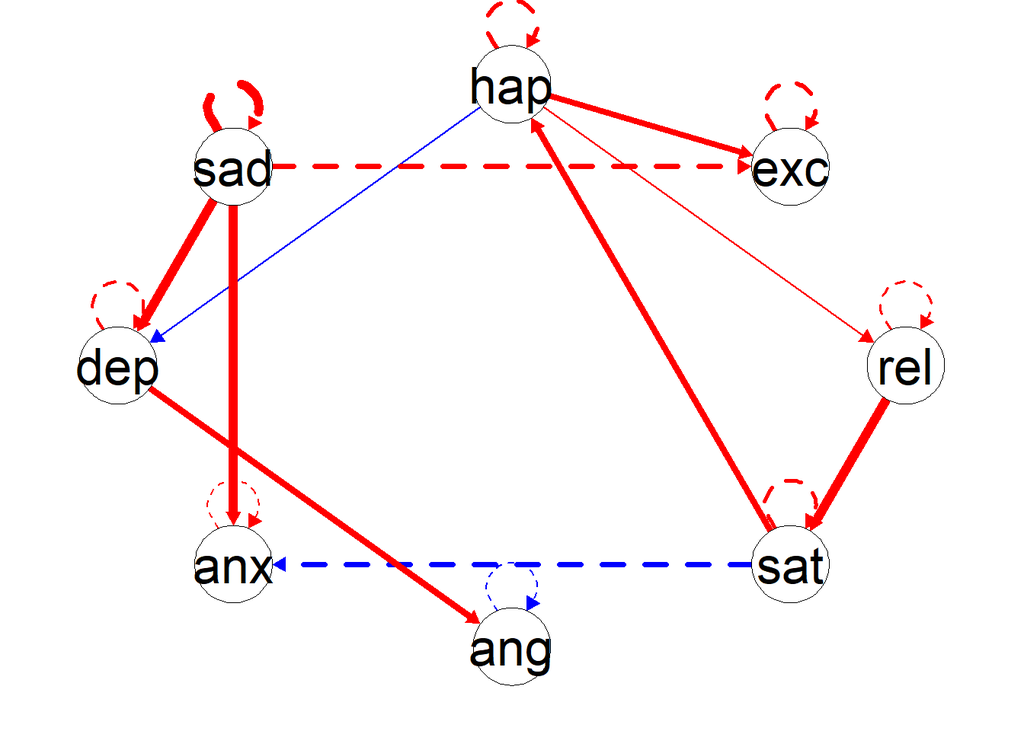

```r
plot(S_GIMME$plots$subj36)
```

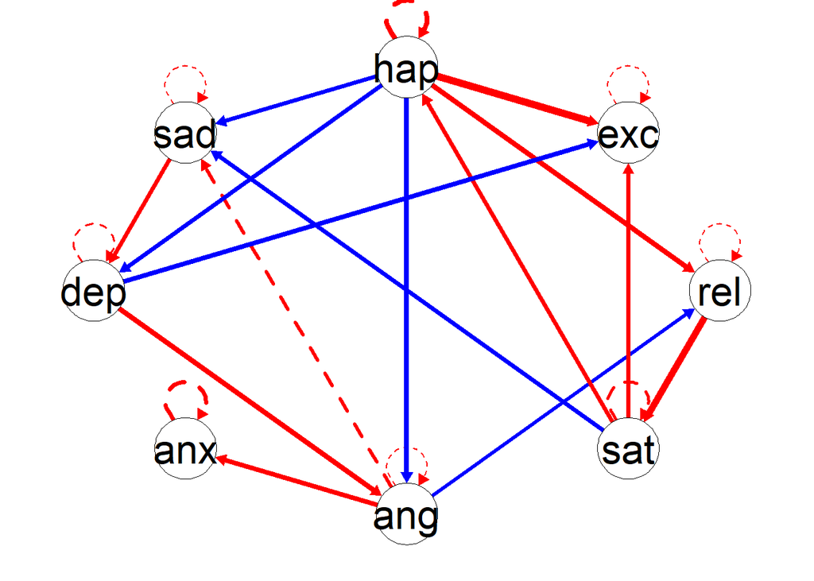

```r
plot(S_GIMME$plots$subj55)
```

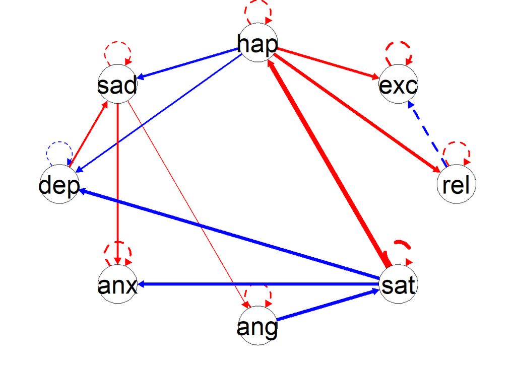

```r
plot(S_GIMME$plots$subj84)
```

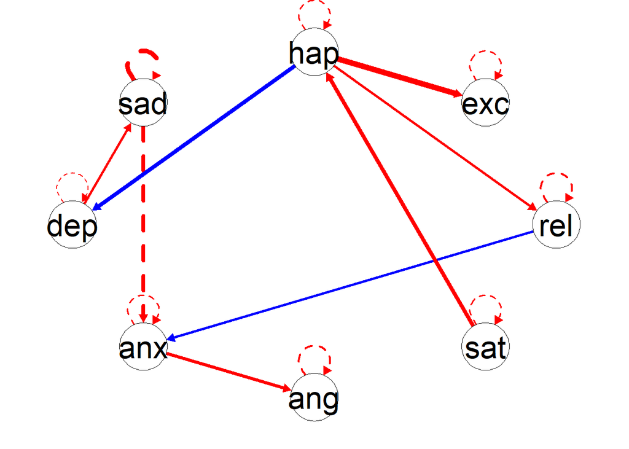

```r
plot(S_GIMME$plots$subj109)
```

**“Number of subgroups = 2” –> so actually detects two groups!**

### check the sub-groups

**Do they correspond to the control and intervention groups? Not really, the estimated sub-groups consist of almost equal number of people from the control and intervention group in the dataset, this holds also for the people who could not be assigned to either one of the S-Gimme groups. Therefore, characterizing these two groups in more detail might be interesting to do in future research.**

```r
# get the subgroup for each individual estimated with S-GIMME --> "sub_membership" column
S_GIMME_output <- as_tibble(S_GIMME$fit %>%
  select(file, sub_membership) %>%
    mutate(file = as.integer(sub("^subj", "", file)))
    )

# get the group (control or mindfulness training) for each individual in the dataset --> "group" column
group_ids <- data %>%
  distinct(group, subjno) %>%
  select(subjno, group)

group_comparison <- group_ids %>%
  left_join(S_GIMME_output %>% select(file, sub_membership),
    by = c("subjno" = "file")
  )

# for the estimated groups with S-GIMME (sub_memberhsip) --> what's the number of people from control or mindfulness training (dataset)
group_comparison %>%
  group_by(sub_membership) %>%
    summarise(
      control_group1 = sum(group == 1, na.rm = TRUE),
      intervention_group2 = sum(group == 2, na.rm = TRUE),
      .groups = "drop"
    )
```

```
## # A tibble: 3 × 3
##   sub_membership control_group1 intervention_group2
##            <dbl>          <int>               <int>
## 1              1             36                  28
## 2              2             16                  18
## 3             NA             12                  15
```

# Original Analysis done in (Rowland & Wenzel 2020)

@article{Rowland.2020.Dataset, author = {Rowland, Zarah and Wenzel, Mario}, year = {2020}, title = {{Mindfulness and Affect-Network Density: Does Mindfulness Facilitate Disengagement from Affective Experiences in Daily Life?}}, pages = {1253–1266}, volume = {11}, number = {5}, issn = {1868-8527}, journal = {Mindfulness}, doi = {10.1007/s12671-020-01335-4} }

code available here: https://osf.io/jmz2n/overview

```r
library("qgraph")
library("graphicalVAR") # https://cran.r-project.org/web/packages/graphicalVAR/index.html

### outcome names
outnames <- c("happy", "excited", "relaxed", "satisfied", "angry","anxious", "depressed", "sad")

dat <- read.table("data_affect.csv", sep=",", header=TRUE, na.strings="")

##sort data
dat <- dat[order(dat$subjno, dat$group, dat$dayno, dat$beep),]

names(dat)[pmatch(c("emo1_m", "emo2_m", "emo3_m", "emo4_m", "emo5_m", "emo6_m", "emo7_m", "emo8_m"),
                  names(dat))] <- outnames

## modeling temporal networks (with https://cran.r-project.org/web/packages/graphicalVAR/index.html)
myData_ind_dat<- mlGraphicalVAR(dat,
                                vars = c("happy", "excited", "relaxed", "satisfied", "angry", "anxious", "depressed", "sad"),
                                dayvar = "dayno",
                                idvar = "subjno",
                                lags = 1,
                                beepvar = "beep",
                                subjectNetworks = TRUE,
                                centerWithin = TRUE,
                                gamma = 0,
                                lambda_kappa = 0,
                                lambda_beta = 0)
```

```
## Estimating fixed networks
```

[output not shown]

```
## Estimating between-subjects network
```

```
## Estimating subject-specific networks
```

[output not shown]

```r
ID = myData_ind_dat$ids

myData_ind_dat$fixedResults$N
```

```
## [1] 14257
```

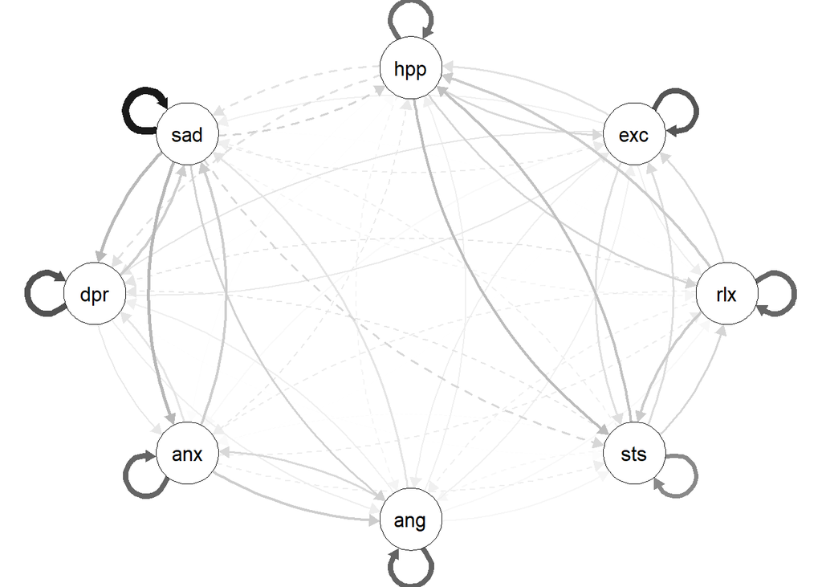

```r
## extracting individuals' temporal network density
t_oad=c()
for (i in 1:125){
  t_oad[i] <- mean(abs(myData_ind_dat$subjectPDC[[i]][1:8, 1:8]))}

t_pad=c()
for (i in 1:125){
  t_pad[i] <- mean(abs(myData_ind_dat$subjectPDC[[i]][1:8, 1:4]))}

t_nad=c()
for (i in 1:125){
  t_nad[i] <- mean(abs(myData_ind_dat$subjectPDC[[i]][1:8, 5:8]))}



## extracting individuals' contemporaneous network density
c_oad=c()
for (i in 1:125){
  c_oad[i] <- ((sum(abs(myData_ind_dat$subjectPCC[[i]][1:8, 1:8]))))/2/28}

c_pad=c()
for (i in 1:125){
  c_pad[i] <- ((sum(abs(myData_ind_dat$subjectPCC[[i]][1:4, 1:4]))))/2/6}

c_nad=c()
for (i in 1:125){
  c_nad[i] <- ((sum(abs(myData_ind_dat$subjectPCC[[i]][5:8, 5:8]))))/2/6}

c_pa_nad=c()
for (i in 1:125){
  c_pa_nad[i] <- ((mean(abs(myData_ind_dat$subjectPCC[[i]][1:4, 5:8]))))}

options(max.print = 99999999)


##extracting temporal single-affect network densities
t_happy=c()
for (i in 1:125){
  t_happy[i] <- mean(abs(myData_ind_dat$subjectPDC[[i]][1:8, 1:1]))}

t_excited=c()
for (i in 1:125){
  t_excited[i] <- mean(abs(myData_ind_dat$subjectPDC[[i]][1:8, 2:2]))}

t_relaxed=c()
for (i in 1:125){
  t_relaxed[i] <- mean(abs(myData_ind_dat$subjectPDC[[i]][1:8, 3:3]))}

t_satisfied=c()
for (i in 1:125){
  t_satisfied[i] <- mean(abs(myData_ind_dat$subjectPDC[[i]][1:8, 4:4]))}

t_angry=c()
for (i in 1:125){
  t_angry[i] <- mean(abs(myData_ind_dat$subjectPDC[[i]][1:8, 5:5]))}

t_anxious=c()
for (i in 1:125){
  t_anxious[i] <- mean(abs(myData_ind_dat$subjectPDC[[i]][1:8, 6:6]))}

t_depressed=c()
for (i in 1:125){
  t_depressed[i] <- mean(abs(myData_ind_dat$subjectPDC[[i]][1:8, 7:7]))}

t_sad=c()
for (i in 1:125){
  t_sad[i] <- mean(abs(myData_ind_dat$subjectPDC[[i]][1:8, 8:8]))}


## combining all individual network densities
all_matrix <- cbind(ID, t_oad, t_pad, t_nad, c_oad, c_pad, c_nad, c_pa_nad, t_happy, t_excited, t_relaxed, t_satisfied, t_angry, t_anxious, t_depressed, t_sad)
write.csv(all_matrix, "all_matrix.csv")



## population networks: Figure 1
qgraph(myData_ind_dat$fixedPDC, layout = "circle", theme = "gray")
```

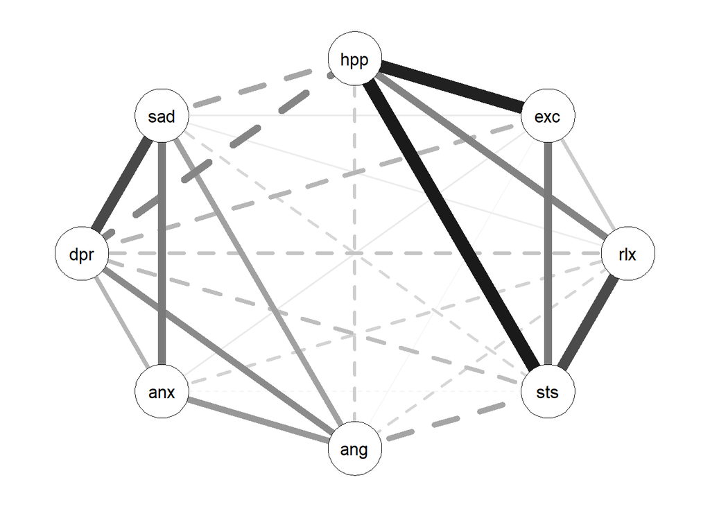

```r
qgraph(myData_ind_dat$fixedPCC, layout = "circle", theme = "gray")
```

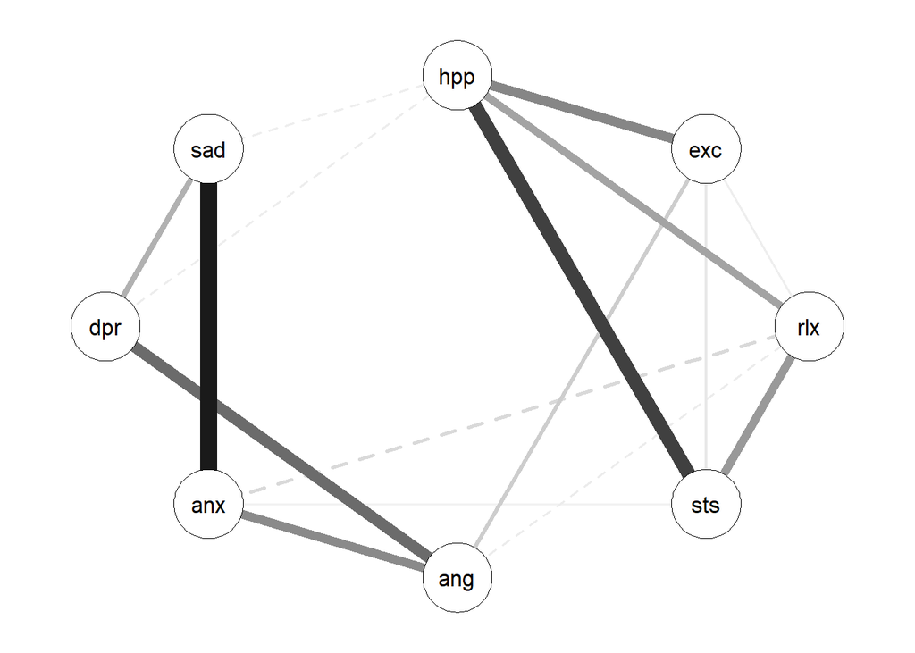

```r
qgraph(myData_ind_dat$betweenNet, layout = "circle", theme = "gray")
```